# pertemuan 11 PDS

2025-04-23

# 1. Data & Preview Data

memuat dataset airquality yang tersedia secara default di R. Dataset ini berisi informasi mengenai kualitas udara harian di New York pada tahun 1973, termasuk variabel seperti Ozone, Solar.R, Wind, Temp, dan Month. dan dilakukan peninjauan awal data untuk memahami struktur dan isi dataset. Di sini saya memilih Ozone sebagai variabel dependen (Y) dan Temp sebagai variabel independen (X).

Model regresi yang akan dibentuk adalah: Ozone∼Temp

```r
data("airquality")

#Preview Data
head(airquality)
```

```
##   Ozone Solar.R Wind Temp Month Day
## 1    41     190  7.4   67     5   1
## 2    36     118  8.0   72     5   2
## 3    12     149 12.6   74     5   3
## 4    18     313 11.5   62     5   4
## 5    NA      NA 14.3   56     5   5
## 6    28      NA 14.9   66     5   6
```

```r
summary(airquality)
```

```
##      Ozone           Solar.R           Wind             Temp
##  Min.   :  1.00   Min.   :  7.0   Min.   : 1.700   Min.   :56.00
##  1st Qu.: 18.00   1st Qu.:115.8   1st Qu.: 7.400   1st Qu.:72.00
##  Median : 31.50   Median :205.0   Median : 9.700   Median :79.00
##  Mean   : 42.13   Mean   :185.9   Mean   : 9.958   Mean   :77.88
##  3rd Qu.: 63.25   3rd Qu.:258.8   3rd Qu.:11.500   3rd Qu.:85.00
##  Max.   :168.00   Max.   :334.0   Max.   :20.700   Max.   :97.00
##  NA's   :37       NA's   :7
##      Month            Day
##  Min.   :5.000   Min.   : 1.0
##  1st Qu.:6.000   1st Qu.: 8.0
##  Median :7.000   Median :16.0
##  Mean   :6.993   Mean   :15.8
##  3rd Qu.:8.000   3rd Qu.:23.0
##  Max.   :9.000   Max.   :31.0
##
```

```r
str(airquality)
```

```
## 'data.frame':    153 obs. of  6 variables:
##  $ Ozone  : int  41 36 12 18 NA 28 23 19 8 NA ...
##  $ Solar.R: int  190 118 149 313 NA NA 299 99 19 194 ...
##  $ Wind   : num  7.4 8 12.6 11.5 14.3 14.9 8.6 13.8 20.1 8.6 ...
##  $ Temp   : int  67 72 74 62 56 66 65 59 61 69 ...
##  $ Month  : int  5 5 5 5 5 5 5 5 5 5 ...
##  $ Day    : int  1 2 3 4 5 6 7 8 9 10 ...
```

# 2. Heatmap Korelasi Data

Visualisasi hubungan antar variabel numerik melalui heatmap korelasi. Korelasi positif antara Temp dan Ozone akan memperkuat alasan pemilihan model.

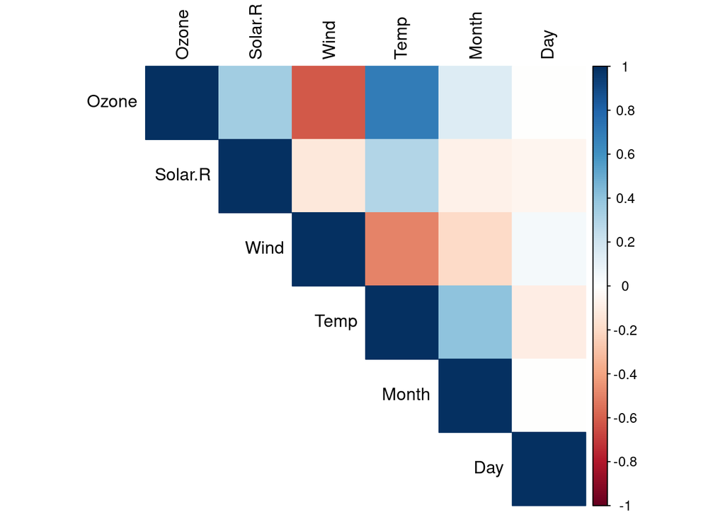

```r
library(corrplot)
aq_clean <- na.omit(airquality)
cor_matrix <- cor(aq_clean)

corrplot(cor_matrix, method = "color", type = "upper", tl.col = "black")
```

```r
model <- lm(Wind ~ Temp, data = airquality)
residuals <- residuals(model)
```

# 3. Uji Asumsi Normalitas

Uji Shapiro-Wilk digunakan untuk memeriksa apakah residual berdistribusi normal. Visualisasi melalui Q-Q plot membantu mendeteksi penyimpangan dari distribusi normal.

```r
model <- lm(Ozone ~ Temp, data = aq_clean)
residuals <- residuals(model)

shapiro.test(residuals)  # H0: residual normal
```

```
##
##  Shapiro-Wilk normality test
##
## data:  residuals
## W = 0.88983, p-value = 1.522e-07
```

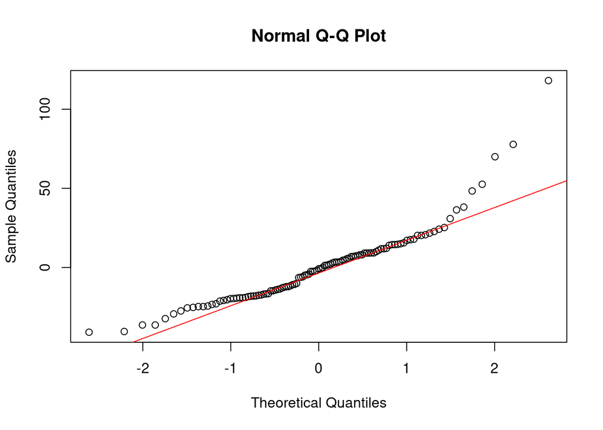

```r
qqnorm(residuals)
qqline(residuals, col = "red")
```

# 4. Uji Asumsi Heteroskedastisitas

Uji Breusch-Pagan digunakan untuk mendeteksi adanya heteroskedastisitas, yaitu kondisi di mana varians residual tidak konstan. Nilai p yang besar (p > 0.05) menandakan tidak ada heteroskedastisitas.

```r
library(lmtest)
bptest(model)
```

```
##
##  studentized Breusch-Pagan test
##
## data:  model
## BP = 1.5088, df = 1, p-value = 0.2193
```

# 5. Uji Asumsi Multikorelineritas

Dalam regresi linear sederhana (satu prediktor), uji ini tidak diperlukan. Namun, jika ditambahkan lebih dari satu prediktor, maka Variance Inflation Factor (VIF) digunakan untuk mendeteksi multikolinieritas antar prediktor.

```r
model2 <- lm(Ozone ~ Temp + Wind, data = aq_clean)
library(car)
vif(model2)
```

```
##    Temp    Wind
## 1.32837 1.32837
```

# 6. Uji Asumsi Autokorelasi

Uji Durbin-Watson digunakan untuk memeriksa autokorelasi pada residual. Nilai mendekati 2 menandakan tidak adanya autokorelasi, yang penting untuk keandalan model regresi.

```r
dwtest(model)
```

```
##
##  Durbin-Watson test
##
## data:  model
## DW = 1.8644, p-value = 0.2123
## alternative hypothesis: true autocorrelation is greater than 0
```

# 7. Pemodelan Regresi

Output dari fungsi summary() menyajikan estimasi koefisien regresi, nilai R-squared, nilai F-statistik, serta signifikansi model. Koefisien regresi akan digunakan untuk membentuk persamaan regresi.

```r
summary(model)
```

```
##
## Call:
## lm(formula = Ozone ~ Temp, data = aq_clean)
##
## Residuals:
##     Min      1Q  Median      3Q     Max
## -40.922 -17.459  -0.874  10.444 118.078
##
## Coefficients:
##              Estimate Std. Error t value Pr(>|t|)
## (Intercept) -147.6461    18.7553  -7.872 2.76e-12 ***
## Temp           2.4391     0.2393  10.192  < 2e-16 ***
## ---
## Signif. codes:  0 '***' 0.001 '**' 0.01 '*' 0.05 '.' 0.1 ' ' 1
##
## Residual standard error: 23.92 on 109 degrees of freedom
## Multiple R-squared:  0.488,  Adjusted R-squared:  0.4833
## F-statistic: 103.9 on 1 and 109 DF,  p-value: < 2.2e-16
```

# 8. R-square

Nilai Multiple R-squared menunjukkan proporsi variasi dalam Ozone yang dapat dijelaskan oleh suhu (Temp). Nilai R-square 0.48 berarti 48% variasi dalam kadar Ozone dijelaskan oleh suhu.

```r
df <- na.omit(airquality)

y_actual <- df$Ozone
y_pred <- predict(model)

SSres <- sum((y_actual - y_pred)^2)
SStot <- sum((y_actual - mean(y_actual))^2)

R_squared_manual <- 1 - (SSres / SStot)

print(paste("R-squared (manual):", round(R_squared_manual, 4)))
```

```
## [1] "R-squared (manual): 0.488"
```

# 9. Interpretasi Data

persamaan regresi:

y =−147.6461+2.4391x

Intercept (-147.6461): Bila suhu = 0°F (nilai ekstrem dan teoritis), prediksi Ozone adalah -147.6461 (tidak realistis, tapi secara matematis diperlukan).

Koefisien Temp (2.4391): Setiap kenaikan 1°F suhu, kadar Ozone meningkat rata-rata sebesar 2.4391 unit.

R-squared 0.48: Sekitar 48% variasi Ozone dapat dijelaskan oleh suhu.